# Hierarchical Clustering Bacteria

Cassandra Sperow

2023-10-09

## Hierarchical Clustering

- Thus far, the Hierarchical Clustering has been more stable than K-Means.

### Read in Revised Proportion-based Bacteria Data

```r
read_csv("../output/rev_bacteria_prop_df.csv") -> rev_bacteria_prop_df
```

- From Ressler Notes:

“Build an upside-down tree starting with leaves and work our way up to build a hierarchy of similar observations within clusters.

We have to make two choices:

A measure for distance, here we are using the L2 Norm but others are possible A method for determining the “linkage” between the clusters so we can calculate their “dissimilarity”. Four common linkages: Complete, Single, Average, and Centroid of which Average and Complete are generally preferred. There are many others. The linkage can affect the shape of the clusters in p-dimensional space.”

Another source considered: https://microbiome.github.io/OMA/clustering.html#hierarchical-clustering

## Method ‘ward.D2’ method mentioned in one of the literature review

- This was mentioned in Yang and Xu (2020) that goes over several methods in relation to microbiome data.

```r
# take out sample id column to only scale numeric ASV proportions
# use dist() for the dissimilarity structure that hclust() takes
stats::hclust(dist(scale(rev_bacteria_prop_df[,-1])), method = "ward.D2") -> hcward
```

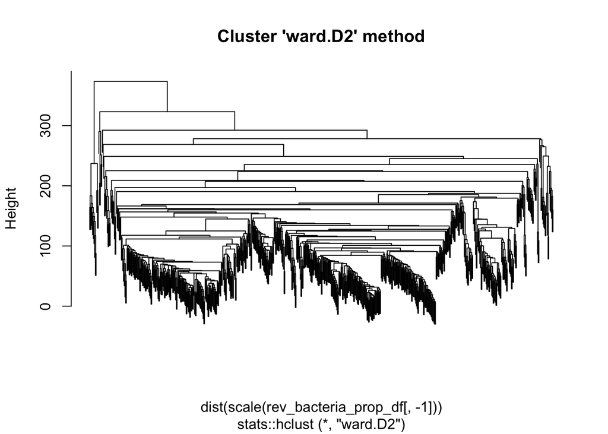

```r
# removing labels for plotting
plot(hcward,
     labels = F,
     main = "Cluster 'ward.D2' method")
```

- Put labels at same hieght - worse looking

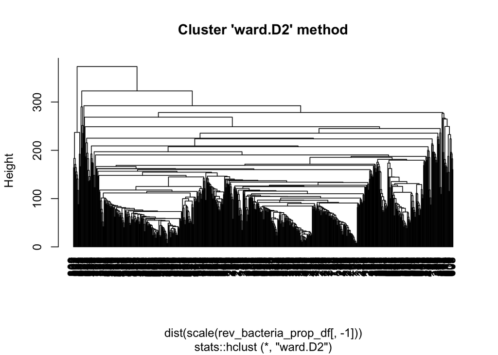

```r
plot(hcward,
     hang = -1,
     #labels = F,
     main = "Cluster 'ward.D2' method")
```

- Convert hclust output into dendrogram and plot

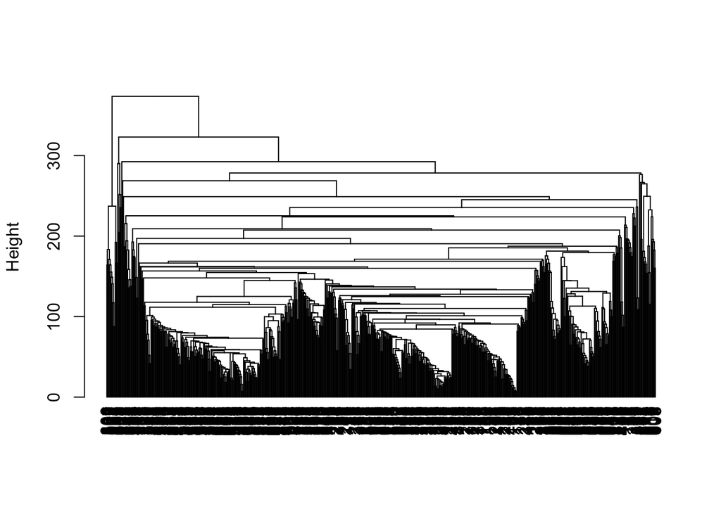

```r
hcward_denro <- as.dendrogram(hcward)

# default plot
plot(hcward_denro, type = "rectangle", ylab = "Height")
```

- Dendrogram Plotting http://www.sthda.com/english/wiki/beautiful-dendrogram-visualizations-in-r-5-must-known-methods-unsupervised-machine-learning
- Zoom in:

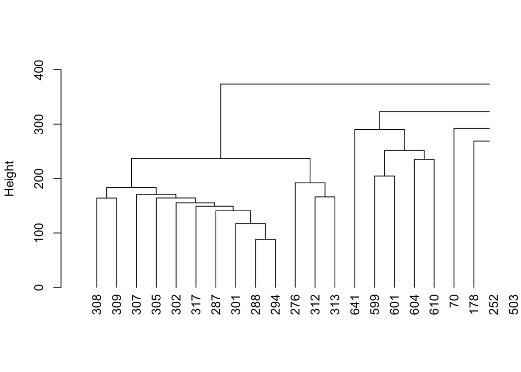

```r
plot(hcward_denro, type = "rectangle", ylab = "Height",
     xlim = c(0,20),
     ylim = c(0, 400))
```

### Package ‘ape’ for plotting dendrograms

```r
library(ape)
```

[figure not shown]

```r
# pass original output object not dendro object
plot(as.phylo(hcward),
     type = "unrooted",
     label.offset = 0.1
     )
```

[figure not shown]

```r
plot(as.phylo(hcward),
     type = "fan",
     label.offset = 0.1
     )
```

### Need to cut tree for reading plots - still doesn’t work

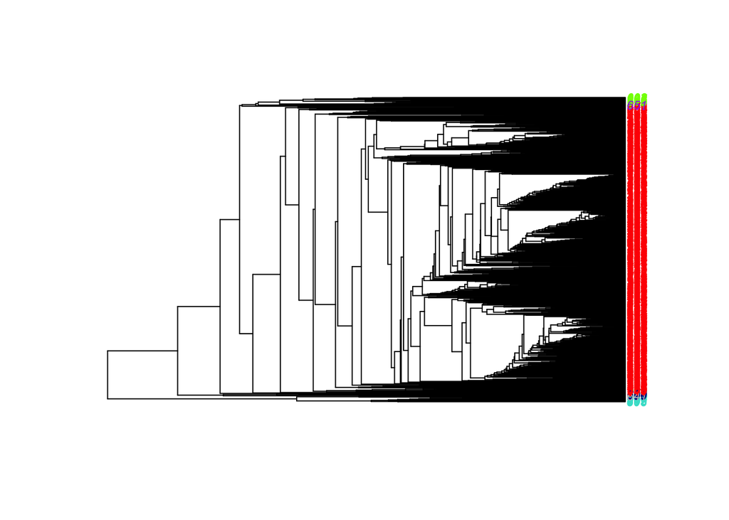

```r
colors = c("red", "blue", "green", "black", "turquoise",
           "pink", "chartreuse", "purple", "darkblue", "gray")
hcward_cut = cutree(hcward, 10)
plot(as.phylo(hcward),
     #type = "radial",
     tip.color = colors[hcward_cut],
     label.offset = 0.5, cex = 0.7)
```

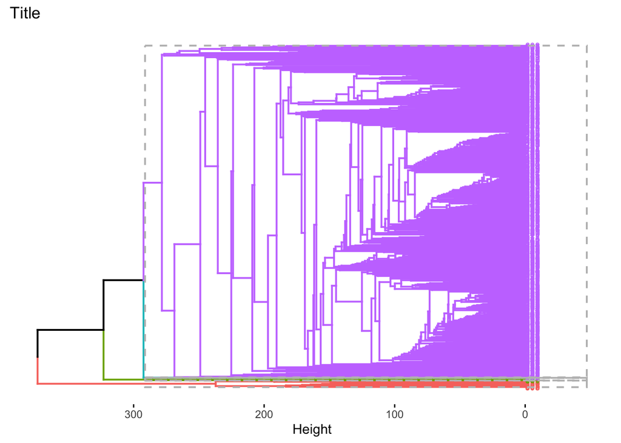

```r
factoextra::fviz_dend(hcward,
          main = "Title",
          show_labels = T,
          cex = 0.5, # size of labels
          rect = TRUE,
          horiz = TRUE,
          repel = T,
          #rect_border = "none",
          #type = "phylogenic",
          h=300) # cut dendrogram at height
```

## Method Centroid

```r
hcentroid <- stats::hclust(dist(scale(rev_bacteria_prop_df[,-1])),
                    method = "centroid")
```

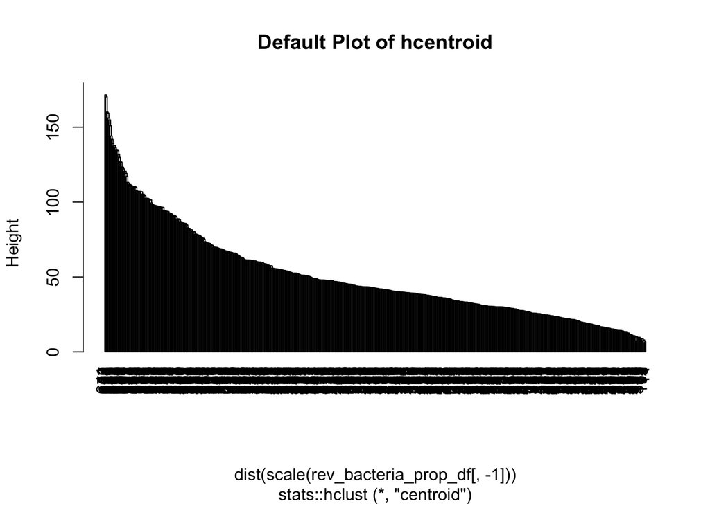

```r
# base R plot of dendrogram
plot(hcentroid,
     main = "Default Plot of hcentroid",
     hang = -1)
```

```r
class(hcentroid)
```

```
## [1] "hclust"
```

[figure not shown]

```r
# factoextra dendogram of hclust output
fviz_dend(hcentroid,
          rect = TRUE,
          cex = 0.5)
```

```r
summary(hcentroid)
```

```
##             Length Class  Mode
## merge       1316   -none- numeric
## height       658   -none- numeric
## order        659   -none- numeric
## labels         0   -none- NULL
## method         1   -none- character
## call           3   -none- call
## dist.method    1   -none- character
```

```r
#hcentroid$order
```

### Cut Tree

```r
hcentroid_cut <- cutree(hcentroid, 20)
# number of members in each cluster after cutting
table(hcentroid_cut)
```

```
## hcentroid_cut
##   1   2   3   4   5   6   7   8   9  10  11  12  13  14  15  16  17  18  19  20
## 640   1   1   1   1   1   1   1   1   1   1   1   1   1   1   1   1   1   1   1
```

```r
length(hcentroid_cut) # 659
```

```
## [1] 659
```

```r
hcentroid_cut[hcentroid_cut >= 150]
```

```
## integer(0)
```

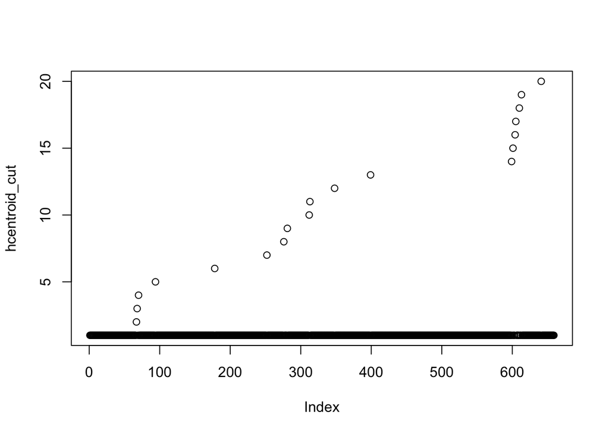

```r
# base R plot of hierarchical clustering output
# with cut tree
plot(hcentroid_cut)
```

——–from previous attempts

```r
#data.frame(hc2, HCC5)
```

```r
# library(dendextend)
# avg_dend_obj <- as.dendrogram(HCC)
# avg_col_dend <- color_branches(avg_dend_obj, h = 3)
# plot(avg_col_dend)
```

```r
# scaled_data %>%
#   as_tibble() %>%
#   mutate(cluster = HCC) %>%
#   group_by(cluster)
```

https://rpkgs.datanovia.com/factoextra/